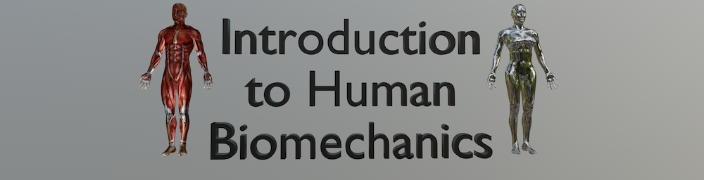

# **Chapter 13** Dynamics III: Muscle Forces

This chapter describes muscle forces, how they are produced, and how they can be calcualted.

- What are muscle forces?
- How do muscles produce forces?
- How can muscle forces be calculated?
- Summary

# What are muscle forces?

Back to Table of Contents

- Muscles, or [skeletal muscles](https://en.wikipedia.org/wiki/Skeletal_muscle), are the stuctures in our body that are responsible for voluntary force production
- Without skeletal muscles, we could not voluntarily move our body segments
- Muscle forces are forces that are *internal* to the whole body
  - Muscle contraction does not affect the acceleration of the whole-body COM
  - **Unless** the body is contacting a surface **and** the surface produces a reaction force against the body
  - For example, when sitting on a swivel chair, raise your feet off the ground and rotate your trunk in the transverse plane; it is not possible to rotationally accelerate your whole body!
  - If instead you put your feet on the ground, it is easy to rotationally accelerate your whole body; this is because the external ground reaction forces accelerate your body
- Muscle forces can be *external* forces for specific body segments
  - For example, the biceps muscle produces an external force on the forearm segment

# How do muscles produce forces?

Back to Table of Contents

- The most thorough explanation of muscle force production is the [sliding filament theory](https://en.wikipedia.org/wiki/Sliding_filament_theory).
- According to the **sliding filament theory**:
  - Myosin molecules have "heads" which change geometric configurations or "contract" (Fig.13.1) when stimulated by muscle nerves
  - The myosin heads pull nearby actin filaments, a little like a hand pulling a rope
  - This in turn pulls actin filaments' anchors ("Z" bands) toward each other (Fig.13.2)
  - Actin filaments and myosin molecules form long [myofibrils](https://en.wikipedia.org/wiki/Myofibril), which are arranged in tight bundles, much like plastic straws in a container.
  - In turn, many long myofibrils are arranged tightly to form muscle fibers
  - In turn, many long muscle fibers are arranged tightly to form muscles
  - This arrangement is like sequentially larger straws arranged in tight bundles
- This contraction model means that muscles can only produce pulling forces, and not pushing forces

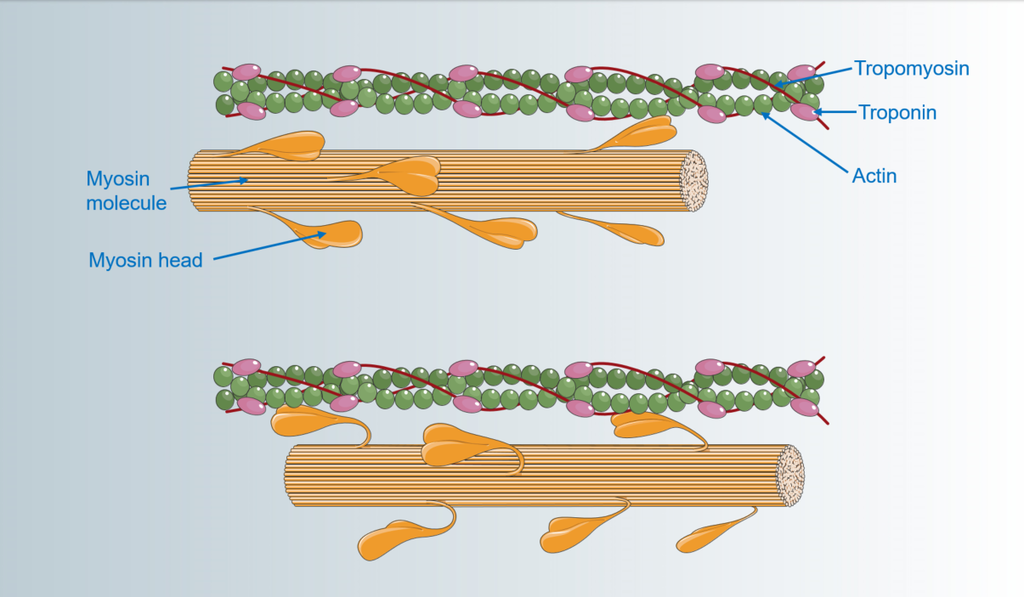

**Figure 13.1**. Image used under a [Creative Commons Attribution-Share Alike 4.0 International license](https://creativecommons.org/licenses/by-sa/4.0/deed.en); user: Jeff16

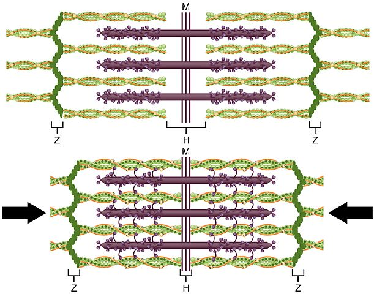

**Figure 13.2**. Image used under a [Creative Commons Attribution 4.0 International license](https://creativecommons.org/licenses/by/4.0/deed.en); user: CFCF

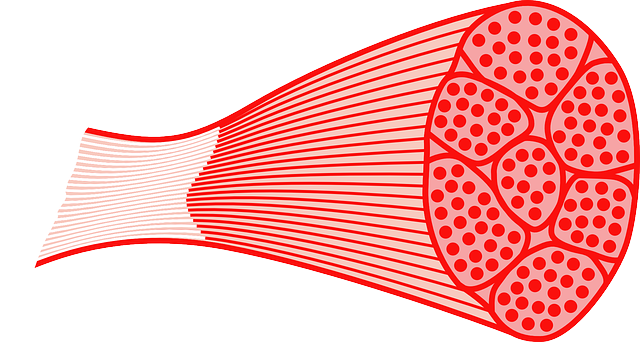

**Figure 13.3**. [Image](https://pixabay.com/vectors/muscle-meat-medicine-anatomy-148107/) used under a Pixbay license.

# How can muscle forces be calculated?

Back to Table of Contents

- Muscle force calculations are highly complex
- For a motion capture experiment, in general one needs to make the following calculations:
  - Required measurements:
    - Marker positions
    - External forces (especially ground reaction force and other contact forces)
  - Required models:
    - Segment lengths
    - Joint motion models
    - Body segment parameters (all inertial properties)
    - Muscle geometry (origin and insertion points)
    - Muscle contraction dynamics (muscles can not produce forces instanteously)
  - Calculation procedure:
    1. Inverse kinematics:
       - Use models of all segments and joints
       - Calculate the joint angles that correspond to the measured marker motion
    2. Inverse dynamics:
       - Use models of all body segments (inertial parameters)
       - Calculate joint reaction forces based on the accelerations that were calculated during inverse kinematics
    3. Muscle force calculation:
       - Use models of muscle geometry and muscle contraction dynamics
       - Calculate the (approximate) minimum muscle forces required to produce the joint reaction forces that were calculated during inverse dynamics
- Each step of this process involves potential errors !

# Summary

Back to Table of Contents

- Muscles produce forces that are internal to our bodies
- For specific body segments, muscle forces are external forces
- Without skeletal muscles, we could not move our bodies voluntarily
- It is thought that muscles produce forces through the contraction of "heads" on myosin molecules
- Muscles are arranged in long, progressively larger structures: myosin and actin, myofibrils, muscle fibers, and eventually whole muscles
- Muscle forces in living humans can be estimated by conducting inverse kinematics, then inverse dynamics, then estimating how many muscles share the calculated joint reaction forces